# Lab03

Collin Loy, Michelle Cryder

September 27, 2018

## Outline

- Find your team members
- Create a repository (one per team) & give access to everybody
- Do a data exploration (on happiness)
- Create an R markdown file that contains all code to read the data and create the plots
- Submit!

# Find your team members

## github repository

1. Log into github
2. Pick one team member to create a repository called ‘lab3’. Make sure to initialize the repo with a README file.
3. Go into the settings of the repository and add your team members as collaborators

## Cloning the repo

1. Open RStudio, create a new repository using the option “Version Control”, choose git as the option
2. From your github repository copy the info you get when clicking on the green “Clone or download” button
3. Paste the info into “Repository URL”
4. Create the project.

This clones the repository from github. You can now make local changes.

## A first round of push and pull

Do these changes one at a time in your team. Don’t try to do them all at once.

1. Make a change to the README document.
2. Go to the ‘Git’ tab in the top right panel.
3. All modified files will have an icon with a white ‘M’ on blue background.
4. Select the checkbox and click on ‘Commit’. Write a commit message in the top right panel of the new dialog window.
5. Hit the green arrow pointing up to ‘push’ changes to your github repo.
6. Hit the blue arrow pointing down to ‘pull’ changes from your github repo.

Commit, and pull, then push often. This will avoid conflicts.

## Background

The General Social Survey (GSS) has been run by NORC every other year since 1972 to keep track of current opinions across the United States.

The package `productplots` contains a subset of this data, called `happy`. You can access the data using the command

```r
data(happy, package="productplots")
head(happy)
```

```
##   id         happy year age    sex       marital         degree
## 1  1 not too happy 1972  23 female never married       bachelor
## 2  2 not too happy 1972  70   male       married lt high school
## 3  3  pretty happy 1972  48 female       married    high school
## 4  4 not too happy 1972  27 female       married       bachelor
## 5  5  pretty happy 1972  61 female       married    high school
## 6  6  pretty happy 1972  26   male never married    high school
##         finrela    health wtssall
## 1       average      good  0.4446
## 2 above average      fair  0.8893
## 3       average excellent  0.8893
## 4       average      good  0.8893
## 5 above average      good  0.8893
## 6 above average      good  0.4446
```

## Updating and cleaning data

Unfortunately, the dataset ends in 2006. So today’s activity is all about updating the dataset to the data from 2016.

An excerpt of the GSS data is available from our course website. Dowload the file `HAPPY.rds` from Canvas (`files\data`) and put the file into a folder called “data” next to your Rmd file. The following command is going to load the data into your R session:

```r
HAPPY <- readRDS("data/HAPPY.rds")
```

You can find a codebook with explanations for each of the variables at https://gssdataexplorer.norc.org/

## Part one (team cleaning)

Answer each of the following questions using R code to get an answer. Write a separate code chunk for each variable, once all the data manipulation is done, show the values in a barchart or histogram and comment on the plot.

1. Data cleaning: the values “IAP”, “DK” and “NA” all encode missing values. Replace all of these instances by the value `NA`.

```r
HAPPY = replace(HAPPY, HAPPY == "IAP", value = NA)
HAPPY = replace(HAPPY, HAPPY == "DK", value = NA)
HAPPY = replace(HAPPY, HAPPY == "NA", value = NA)
```

2. Check the type of the variable and cast into the right type (factor variable for categorical variables). For age, change “89 OR OLDER” to 89 and assume the variable should be numeric.

```r
str(HAPPY)
```

```
## 'data.frame':    62466 obs. of  11 variables:
##  $ HAPPY   : chr  "NOT TOO HAPPY" "NOT TOO HAPPY" "PRETTY HAPPY" "NOT TOO HAPPY" ...
##  $ YEAR    : int  1972 1972 1972 1972 1972 1972 1972 1972 1972 1972 ...
##  $ AGE     : chr  "23" "70" "48" "27" ...
##  $ SEX     : chr  "FEMALE" "MALE" "FEMALE" "FEMALE" ...
##  $ MARITAL : chr  "NEVER MARRIED" "MARRIED" "MARRIED" "MARRIED" ...
##  $ DEGREE  : chr  "BACHELOR" "LT HIGH SCHOOL" "HIGH SCHOOL" "BACHELOR" ...
##  $ FINRELA : chr  "AVERAGE" "ABOVE AVERAGE" "AVERAGE" "AVERAGE" ...
##  $ HEALTH  : chr  "GOOD" "FAIR" "EXCELLENT" "GOOD" ...
##  $ WTSSALL : num  0.445 0.889 0.889 0.889 0.889 ...
##  $ PARTYID : chr  "IND,NEAR DEM" "NOT STR DEMOCRAT" "INDEPENDENT" "NOT STR DEMOCRAT" ...
##  $ POLVIEWS: chr  NA NA NA NA ...
```

```r
replace(HAPPY, HAPPY == "89 OR OLDER", 89)
```

[output not shown]

[output cut: 27259 more lines]

```r
HAPPY$AGE = as.numeric(HAPPY$AGE)
HAPPY$HAPPY = factor(HAPPY$HAPPY)
HAPPY$SEX = factor(HAPPY$SEX)
HAPPY$MARITAL = factor(HAPPY$MARITAL)
HAPPY$DEGREE = factor(HAPPY$DEGREE)
HAPPY$FINRELA = factor(HAPPY$FINRELA)
HAPPY$HEALTH = factor(HAPPY$HEALTH)
HAPPY$PARTYID = factor(HAPPY$PARTYID)
HAPPY$POLVIEWS = factor(HAPPY$POLVIEWS)
str(HAPPY)
```

```
## 'data.frame':    62466 obs. of  11 variables:
##  $ HAPPY   : Factor w/ 3 levels "NOT TOO HAPPY",..: 1 1 2 1 2 2 1 1 2 2 ...
##  $ YEAR    : int  1972 1972 1972 1972 1972 1972 1972 1972 1972 1972 ...
##  $ AGE     : num  23 70 48 27 61 26 28 27 21 30 ...
##  $ SEX     : Factor w/ 2 levels "FEMALE","MALE": 1 2 1 1 1 2 2 2 1 1 ...
##  $ MARITAL : Factor w/ 5 levels "DIVORCED","MARRIED",..: 3 2 2 2 2 3 1 3 3 2 ...
##  $ DEGREE  : Factor w/ 5 levels "BACHELOR","GRADUATE",..: 1 5 3 1 3 3 3 1 3 3 ...
##  $ FINRELA : Factor w/ 5 levels "ABOVE AVERAGE",..: 2 1 2 2 1 1 1 2 2 3 ...
##  $ HEALTH  : Factor w/ 4 levels "EXCELLENT","FAIR",..: 3 2 1 3 3 3 1 3 1 2 ...
##  $ WTSSALL : num  0.445 0.889 0.889 0.889 0.889 ...
##  $ PARTYID : Factor w/ 8 levels "IND,NEAR DEM",..: 1 4 3 4 7 1 1 1 7 7 ...
##  $ POLVIEWS: Factor w/ 7 levels "CONSERVATIVE",..: NA NA NA NA NA NA NA NA NA NA ...
```

3. Bring all levels of factors into a sensible order. For marital you could e.g. order the levels according to average age.

```r
#HAPPY2 = HAPPY
#with(HAPPY2, HAPPY2[order(MARITAL, AGE),])
levels(reorder(HAPPY$MARITAL, HAPPY$AGE, FUN = mean, na.rm=TRUE))
```

```
## [1] "NEVER MARRIED" "SEPARATED"     "MARRIED"       "DIVORCED"
## [5] "WIDOWED"
```

```r
levels(factor(HAPPY$POLVIEWS, levels = c("EXTREMELY LIBERAL", "LIBERAL", "SLIGHTLY LIBERAL", "MODERATE", "SLIGHTLY CONSERVATIVE", "CONSERVATIVE", "EXTRMLY CONSERVATIVE")))
```

```
## [1] "EXTREMELY LIBERAL"     "LIBERAL"               "SLIGHTLY LIBERAL"
## [4] "MODERATE"              "SLIGHTLY CONSERVATIVE" "CONSERVATIVE"
## [7] "EXTRMLY CONSERVATIVE"
```

```r
levels(factor(HAPPY$DEGREE, levels=c("LT HIGH SCHOOL", "HIGH SCHOOL", "JUNIOR COLLEGE", "BACHELOR", "GRADUATE")))
```

```
## [1] "LT HIGH SCHOOL" "HIGH SCHOOL"    "JUNIOR COLLEGE" "BACHELOR"
## [5] "GRADUATE"
```

```r
levels(HAPPY$DEGREE) = c("Some HS", "HS", "JC", "BA", "GRADUATE")

levels(factor(HAPPY$FINRELA, levels=c("FAR ABOVE AVERAGE", "ABOVE AVERAGE", "AVERAGE", "BELOW AVERAGE", "FAR BELOW AVERAGE")))
```

```
## [1] "FAR ABOVE AVERAGE" "ABOVE AVERAGE"     "AVERAGE"
## [4] "BELOW AVERAGE"     "FAR BELOW AVERAGE"
```

```r
levels(HAPPY$FINRELA) = c("FAR ABOVE", "ABOVE", "AVG", "BELOW", "FAR BELOW")

levels(factor(HAPPY$HEALTH, levels = c("EXCELLENT", "GOOD", "FAIR", "POOR")))
```

```
## [1] "EXCELLENT" "GOOD"      "FAIR"      "POOR"
```

```r
levels(factor(HAPPY$HAPPY, levels = c("NOT TOO HAPPY", "PRETTY HAPPY", "VERY HAPPY")))
```

```
## [1] "NOT TOO HAPPY" "PRETTY HAPPY"  "VERY HAPPY"
```

## Part two (individual exploration)

*Happiness!*

Investigate the relationship between happiness and two other variables in the data. Find a visualization that captures the relationship and write a paragraph to describe it. + First Graph: + The first graph shows rhe relationship between happiness and marriage for each gender. + Most people seem to label themselves as pretty happy happy and the largest subcatagory in that for both genders is Married. + Out of the very happy people; the majority are married. + This graph indicates thats Marriage most likely has a positive impact on happiness.

- Second Graph (Michelle):
  - Displays how degree level and financial status relates to happiness.
  - The people that are least happy have below average financial status.
  - Most people label themselves as “pretty happy”
  - Financial status seems to have a greater impact on happiness.

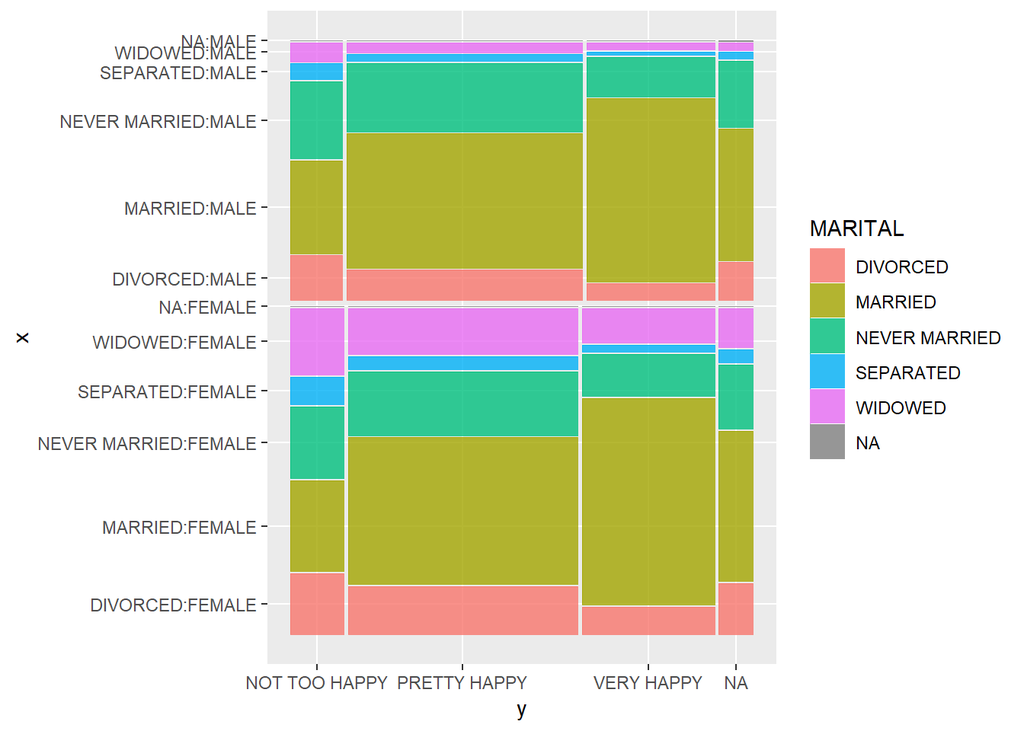

```r
library(ggplot2)
library(ggmosaic)
ggplot(data = HAPPY) +
  geom_mosaic(aes(x = product(HAPPY, SEX), fill=MARITAL, weight=1)) + coord_flip()
```

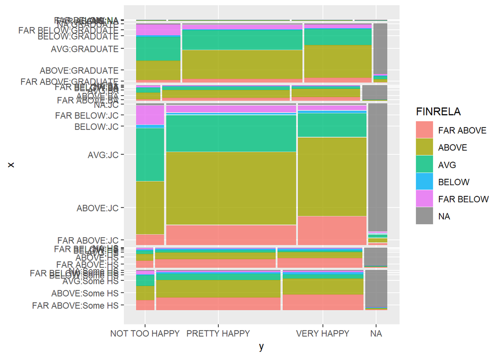

```r
ggplot(data = HAPPY) + geom_mosaic(aes(x = product(HAPPY, DEGREE), fill = FINRELA, weight = 1)) + coord_flip()
```

Each member should study a different question (choose different variables to investigate).

Upload your answers and the dataset to the repository. Discuss and refine answers as a team.

## Submission

In Canvas, submit an RMarkdown file (and the knitted html document) with:

1. the names of all team members that worked on the document.
2. a link to the github repo you were working in.
3. code and answers to all of the questions.
4. for the individual exploration, put the name of the team member beside each question you investigated.
5. you can upload the data file, but you don’t have to

Due date: You have time until Monday at 10 pm to submit the final RMmarkdown file.